# BikeFlow: Investigating User Behavior in the FordGo Bike Sharing Network

## Univariate Exploration

> I'll start by checking the count of user_types for all trips

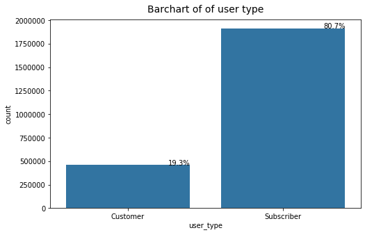

```python
#plot a chart to show user type
plt.figure(figsize=[8, 5])
default_color = sns.color_palette()[0]
ut = sns.countplot(data = df_, x = 'user_is_subscriber', color=default_color)

ticks = [0, 1]
labels = ['Customer', 'Subscriber']
plt.xticks(ticks, labels)

plt.xlabel('user_type')
plt.title('Barchart of of user type', fontsize=14, y=1.015)

total = float(len(df_))
for p in ut.patches:
    percentage = '{:.1f}%'.format(100 * p.get_height()/total)
    x = p.get_x() + p.get_width()
    y = p.get_height()
    ut.annotate(percentage, (x, y),ha='right')

plt.show()
```

the chart above shows the counts of trips for the user types, most users of Bay Wheels are subscribers.

next i will check for the trip count for each month for the entire year 2019

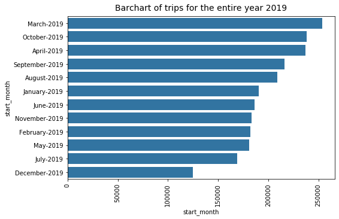

```python
#plot a chart for the entire year
plt.figure(figsize=[8, 5])

freq = df_['start_month'].value_counts()

# Get the indexes of the Series
month_order = freq.index
sns.countplot(data = df_, y = 'start_month', color=default_color,order= month_order )

plt.xlabel('start_month')
plt.xticks(rotation='vertical')
plt.title('Barchart of trips for the entire year 2019', fontsize=14, y=1.015)

plt.show()
```

the chart shows the trips for each month for the entire year of 2019. most trips were taken in the month of march in 2019.

next i will check the linear scale for trip duration in minutes

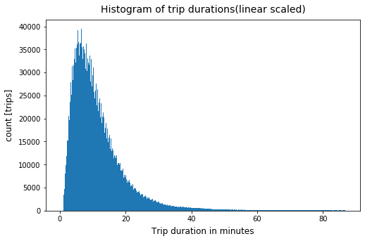

```python
# Plot a histogram of the "duration" column
plt.figure(figsize=[8, 5])
bins = np.arange(0, df_['duration'].max()+0.2, 0.2)
plt.hist(data = df_, x = 'duration', bins=bins);
plt.title('Histogram of trip durations(linear scaled)', fontsize=14, y=1.015)
plt.xlabel('Trip duration in minutes', labelpad=6, fontsize=12)
plt.ylabel('count [trips]', labelpad=6, fontsize=12)
plt.show()
```

there's a long tail in the distribution, so let's put it on a log scale instead. since most trip duration are less than 30minutes, i'm going to add a limit of 30 on the x axis, this is to normalize the distribution

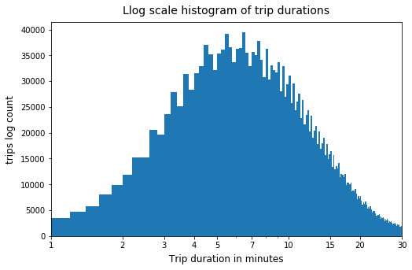

```python
# Apply log scale to the x-axis, increase bin size
plt.figure(figsize=[8, 5])
bins = np.arange(0, 100, 0.2)
ticks = [1, 2, 3, 4, 5, 7, 10, 15, 20, 30, 50, 85]
labels = ['{}'.format(v) for v in ticks]
plt.hist(data = df_, x = 'duration', bins=bins);
plt.xscale('log')
plt.xticks(ticks, labels);
plt.xlim((1,30));
plt.title('Llog scale histogram of trip durations', fontsize=14, y=1.015)
plt.xlabel('Trip duration in minutes', labelpad=6, fontsize=12)
plt.ylabel('trips log count', labelpad=6, fontsize=12)
plt.show()
```

the distribution appears to be almost normal, but rough

next, i will check for the busiest days i.e days that has the highest trips

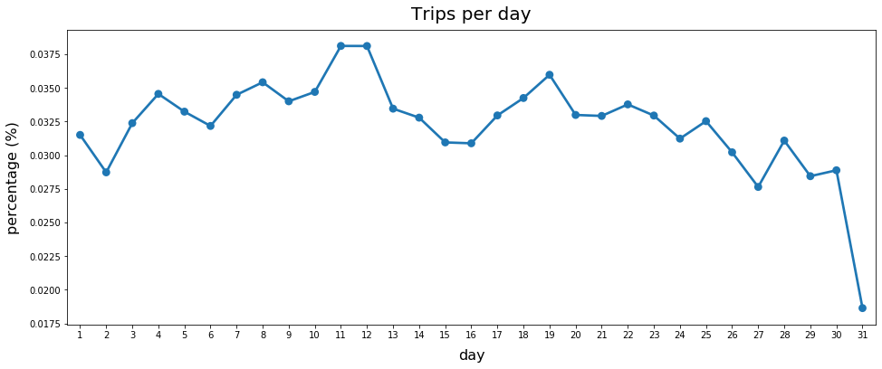

```python
# Days with most trips
trips = (df_['start_time'].dt.day.value_counts().sort_index())/df_.shape[0]#dividing sorted start_time row by it's row

# Point plot for daily rides
rcParams['figure.figsize'] = 16,6
sns.pointplot(x=trips.index, y=trips.values, color = default_color);
plt.title('Trips per day', fontsize=20, y=1.015)
plt.xlabel('day', labelpad=10, fontsize=16)
plt.ylabel('percentage (%)', labelpad=10, fontsize=16);
```

as shown in the chart, the most busy day appears to be 11th and 12th day of the month with the most trips, but drops significantly on the 15th, 16th and 27th day.

now i'll check for hour of the day with most trips

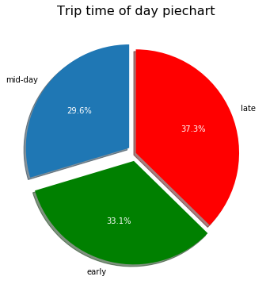

```python
# plotting the pie chart with percentage of time of day
_, _,  autotexts = plt.pie(df_['trip_time_of_day'].value_counts(), labels = ['late', 'early', 'mid-day'],
        colors=['r', 'g', default_color], startangle = 90, counterclock = False, shadow = True,
        explode = (0, 0.08, 0.08), radius = 1.0, autopct = '%1.1f%%')
# Change autopct text color to be white
for ins in autotexts:
    ins.set_color('white')
# Set plot title
plt.title('Trip time of day piechart', fontsize=16, y=1.015)
plt.rcParams['font.size'] = 16
# showing the plot
plt.show()
```

as shown in the pie slice, most trips are taken at late hour of the day, i will check this in bar chart for a clearer visualization

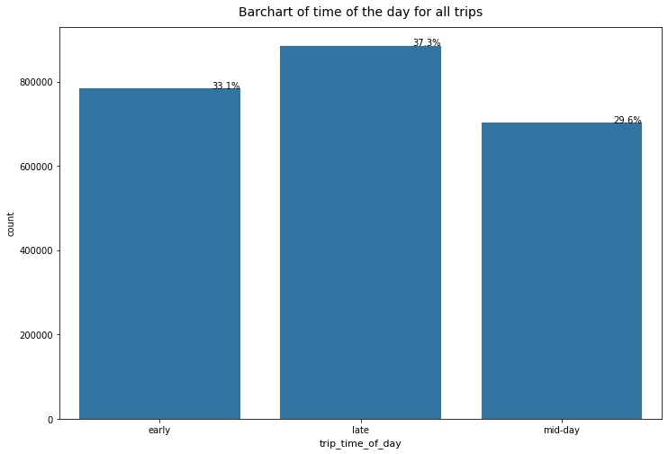

```python
#ploting a barchart for hour of the day with most trips
plt.figure(figsize=[12, 8])

ax = sns.countplot(data = df_, x = 'trip_time_of_day', color=default_color, )
total = float(len(df_))

plt.xlabel('trip_time_of_day', fontsize=11)
plt.title('Barchart of time of the day for all trips', fontsize=14, y=1.015)

#including pecentage value at each bar
for p in ax.patches:
    percentage = '{:.1f}%'.format(100 * p.get_height()/total)
    x = p.get_x() + p.get_width()
    y = p.get_height()
    ax.annotate(percentage, (x, y),ha='right')

plt.show()
```

it seem most trips are taken at late time of the day, i'll check for the exact hour in which this trips are taken

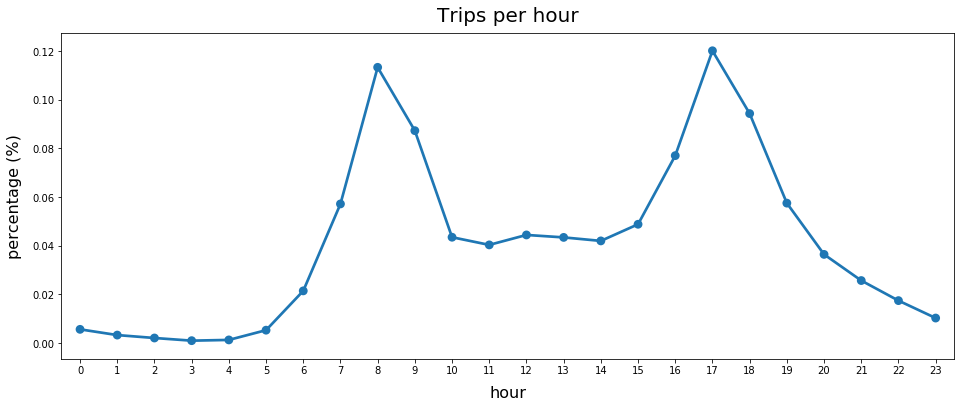

```python
# Hours with most trips
trips_per_hour = (df_['start_time'].dt.hour.value_counts().sort_index())/df_.shape[0]
# Point plot for hourly rides
sns.pointplot(x=trips_per_hour.index, y=trips_per_hour.values, color = default_color);
plt.title('Trips per hour', fontsize=20, y=1.015)
plt.xlabel('hour', labelpad=10, fontsize=16)
plt.ylabel('percentage (%)', labelpad=10, fontsize=16);
```

as seen, many people prefer to take trips at early hours of the day between the hours of 7-9am and at late hours between the hours of 4-6pm.

next, i'll check bike rides for each week day next. i.e day of the week with the most bike ride

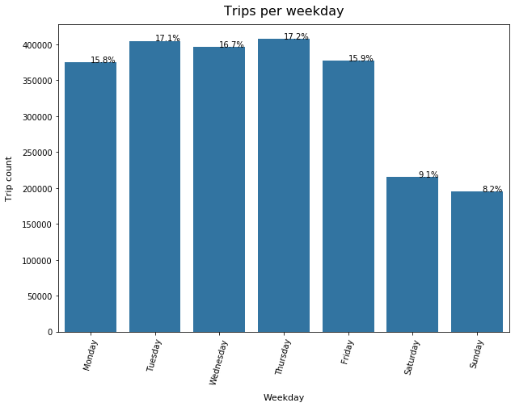

```python
# Bike rides per weekday
rcParams['figure.figsize'] = 10,7
#declaring label for the weekday
weekday = ['Monday', 'Tuesday', 'Wednesday', 'Thursday', 'Friday', 'Saturday', 'Sunday']

wd = sns.countplot(data=df_, x=df_['start_time'].dt.day_name(), order=weekday, color=default_color)
plt.title('Trips per weekday', fontsize=16, y=1.015)
plt.xlabel('Weekday', labelpad=10, fontsize=11)
plt.ylabel('Trip count', labelpad=10, fontsize=11);

#including percentage value for each bar
total = float(len(df_))
for p in wd.patches:
    percentage = '{:.1f}%'.format(100 * p.get_height()/total)
    x = p.get_x() + p.get_width()
    y = p.get_height()
    wd.annotate(percentage, (x, y),ha='right')

plt.xticks(rotation=75);
```

it seems that most trips are taken during weekdays rather than weekends. thursdays and teusdays seem to be the most prefered days to take a trip.

next i'll check for the most popular start stations

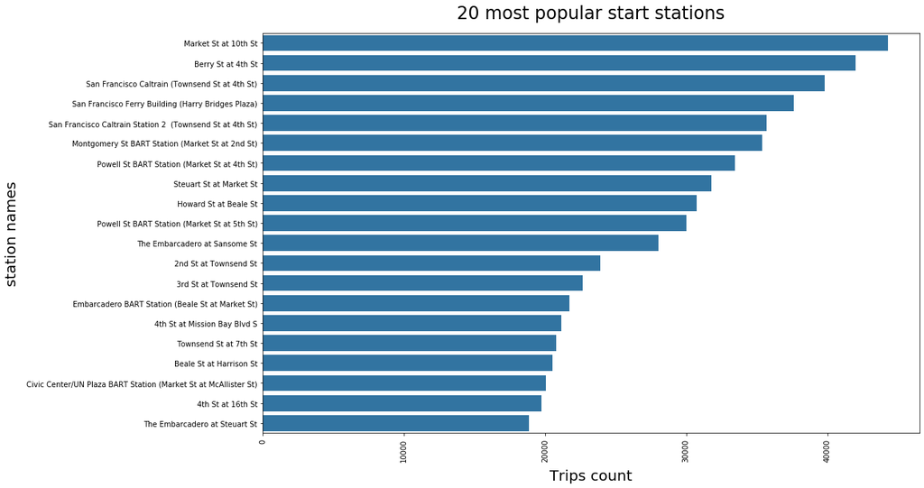

```python
# Exploring most popular stations
top_20_start_stations = df_['start_station_name'].value_counts()[:20]
top_20_end_stations = df_['end_station_name'].value_counts()[:20]

# 20 most popular start stations
rcParams['figure.figsize'] = 16,10
sns.barplot(x=top_20_start_stations, y=top_20_start_stations.index, color=default_color)
plt.title('20 most popular start stations', fontsize=24, y=1.025)
plt.xlabel('Trips count', labelpad=10, fontsize=20)
plt.ylabel('station names', labelpad=10, fontsize=20)

plt.xticks(rotation=90);
```

this show the top 20 starting stations in which trips are taken, i'll also check for the top 20 ending stations

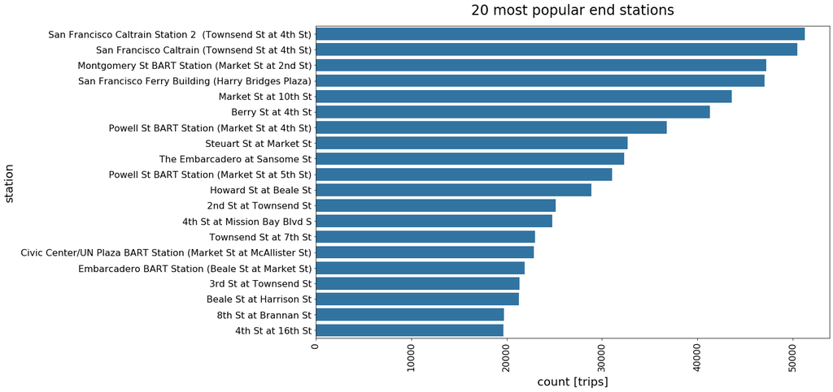

```python
# 20 most popular end stations
rcParams['figure.figsize'] = 16,10
sns.barplot(x=top_20_end_stations, y=top_20_end_stations.index, color=default_color)
plt.title('20 most popular end stations', fontsize=24, y=1.025)
plt.xlabel('count [trips]', labelpad=10, fontsize=20)
plt.ylabel('station', labelpad=10, fontsize=20)

plt.xticks(rotation=90);
```

### Discuss the distribution(s) of your variable(s) of interest. Were there any unusual points? Did you need to perform any transformations?

> the distribution of duration is extremly skewed to the right. After applying the log transformation and setting a limit on the x-axis in attempt to normalize the disribution, the distribution became roughly normal.

### Of the features you investigated, were there any unusual distributions? Did you perform any operations on the data to tidy, adjust, or change the form of the data? If so, why did you do this?

> I included a start month for all trips which displays the name of th month for easy identification, i also included a category data of trip_time_of_day which tells if the trip was taken early, late or mid-day for easy analysis and i added a dummy variable of is_weekend to know if a trip is taken on a weekday or on a weekend with 1 as weekend and 0 as weekday, finally, i also created a time_diff column which was gotten by subtracting start_time from end_time after converting both to date_time data type to spot outliers

## Bivariate Exploration

> To start off with, i'll check for a correlation between numeric data of a sample of 10000 data of the entire data frame

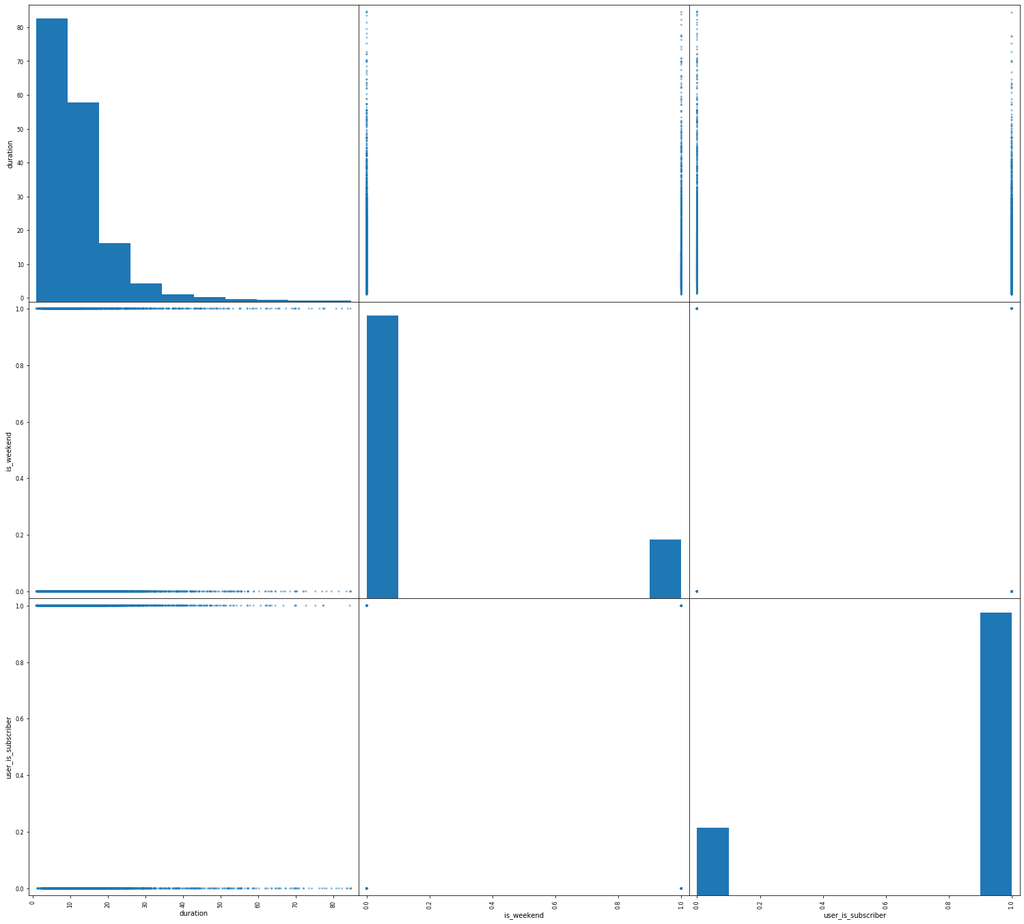

```python
# plot matrix: sample of 10000  so that plots are clearer and they render faster
dff = df_.sample(n=10000)
pd.plotting.scatter_matrix(dff, figsize=(26,24));
```

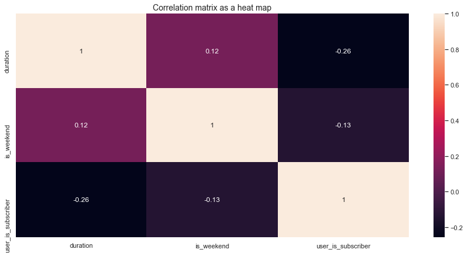

```python
# Check for linear correlation
corr_df = df_.corr()
sns.set(rc={'figure.figsize':(15,7)})
sns.heatmap(corr_df, annot=True)
plt.title('Correlation matrix as a heat map', fontsize=14, y=1.025)
plt.show();
```

Looking at my variable of interest, duration; it seems it has weak linear correlation with user type; and a very weak linear correlation with weekday.

First, i'll check the relationship between duration and user type

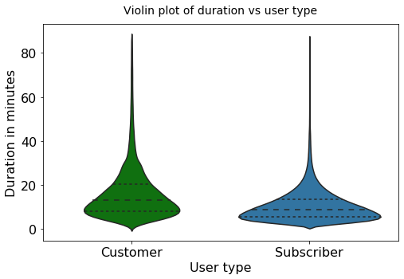

```python
# Violin plot of `is_subscriber` vs `duration`
rcParams['figure.figsize'] = 8,5
sns.violinplot(data=df_, x='user_is_subscriber', y='duration', inner='quartile', palette=['g', default_color])

plt.xticks(ticks, labels)
plt.title('Violin plot of duration vs user type', fontsize=14, y=1.025)
plt.xlabel('User type')
plt.ylabel('Duration in minutes');
```

customers tend to have more duration in their trips than subscribers and there seem to be outliers in violin plot for subscribers depicted with a longer thin tail

next, i'll check duration vs. weekday

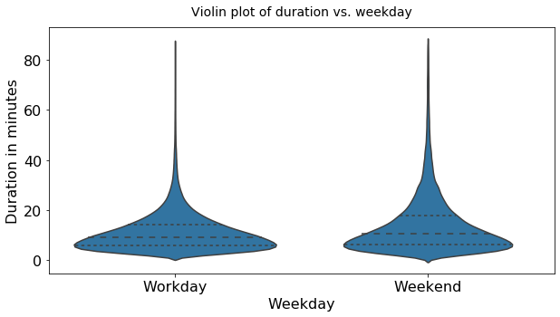

```python
# Violin plot of `duration` vs `is_weekend`
# weekdays tend to have shorter trips
rcParams['figure.figsize'] = 10,5
sns.violinplot(data=df_, x='is_weekend', y='duration', color = default_color, inner='quartile')
ticks = [0, 1]
labels = ['Workday', 'Weekend']
plt.xticks(ticks, labels)
plt.title('Violin plot of duration vs. weekday', fontsize=14, y=1.025)
plt.xlabel('Weekday')
plt.ylabel('Duration in minutes');
```

on average, it seems trips on weekends tend to be slightly longer than on weekdays and has less outliers and more spread distribution

now, i'll start comparing trips in terms of hour, day, weekday, and month for both user types

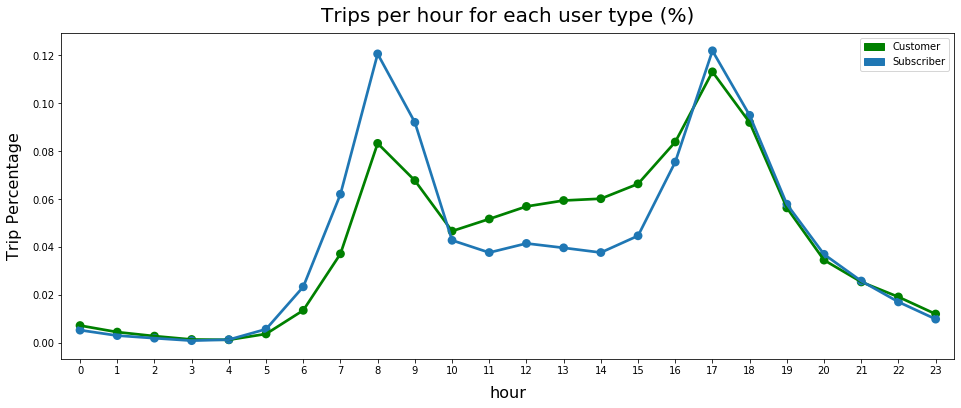

```python
# Creating masks for each user type
customer = df_['user_is_subscriber'] == 0
subscriber = df_['user_is_subscriber'] == 1

# Hours with most trips per user type
customer_hourly_trips = (df_.start_time[customer].dt.hour.value_counts().sort_index())/df_[customer].shape[0]
subscriber_hourly_trips = (df_.start_time[subscriber].dt.hour.value_counts().sort_index())/df_[subscriber].shape[0]

# Point plot for hourly rides per user type
rcParams['figure.figsize'] = 16,6
fig, ax = plt.subplots()
sns.pointplot(x=customer_hourly_trips.index, y=customer_hourly_trips.values, color='g')
sns.pointplot(x=subscriber_hourly_trips.index, y=subscriber_hourly_trips.values, color=default_color)
plt.title('Trips per hour for each user type (%)', fontsize=20, y=1.015)
plt.xlabel('hour', labelpad=10, fontsize=16)
plt.ylabel('Trip Percentage', labelpad=10, fontsize=16)

# Creating artists specifically for adding to the legend (Proxy artists)
customer_legend = mpatches.Patch(color='g', label='Customer')
subscriber_legend = mpatches.Patch(color=default_color, label='Subscriber')
plt.legend(handles=[customer_legend, subscriber_legend])
plt.show();
```

for both users, trips peak around the hours of 8-9am and 5-6pm but drops around 10am - 3pm. though it seems to drop more significantly for subscribers

next, Trips per day for each user type

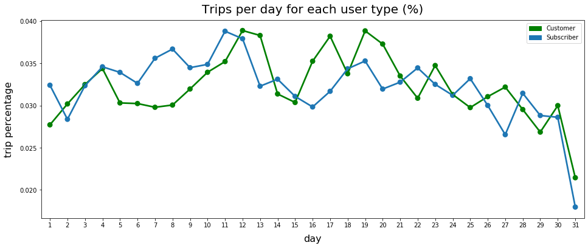

```python
# Days with most trips per user type
customer_daily_trips = (df_.start_time[customer].dt.day.value_counts().sort_index())/df_[customer].shape[0]
subscriber_daily_trips = (df_.start_time[subscriber].dt.day.value_counts().sort_index())/df_[subscriber].shape[0]

# Point plot for daily rides per user type
rcParams['figure.figsize'] = 16,6
fig, ax = plt.subplots()
sns.pointplot(x=customer_daily_trips.index, y=customer_daily_trips.values, color='g')
sns.pointplot(x=subscriber_daily_trips.index, y=subscriber_daily_trips.values, color=default_color)
plt.title('Trips per day for each user type (%)', fontsize=20, y=1.015)
plt.xlabel('day', labelpad=10, fontsize=16)
plt.ylabel('trip percentage', labelpad=10, fontsize=16)

# Creating artists specifically for adding to the legend (Proxy artists)
customer_legend = mpatches.Patch(color='g', label='Customer')
subscriber_legend = mpatches.Patch(color=default_color, label='Subscriber')
plt.legend(handles=[customer_legend, subscriber_legend])
plt.show();
```

customer's trips tends to peak on the 12th, 13th and 19th day but seems to drop significantly on the 14th and 15th day, while for subscribers, it peaks on the 11th and 12th day but drops on the 15th and 27th day

next, i will check and comapare Trips per weekday for each user type

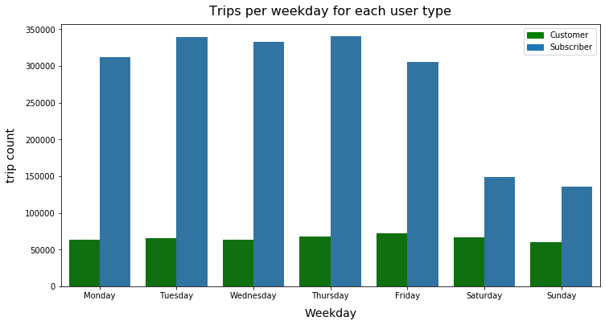

```python
# Bike rides per weekday for each user type
rcParams['figure.figsize'] = 12,6
weekday = ['Monday', 'Tuesday', 'Wednesday', 'Thursday', 'Friday', 'Saturday', 'Sunday']
sns.countplot(data=df_, x=df_['start_time'].dt.day_name(), hue='user_is_subscriber', order=weekday, palette=['g', default_color])
plt.title('Trips per weekday for each user type', fontsize=16, y=1.015)
plt.xlabel('Weekday', labelpad=10, fontsize=14)
plt.ylabel('trip count', labelpad=10, fontsize=14)

# Creating artists specifically for adding to the legend (Proxy artists)
customer_legend = mpatches.Patch(color='g', label='Customer')
subscriber_legend = mpatches.Patch(color=default_color, label='Subscriber')
plt.legend(handles=[customer_legend, subscriber_legend])
plt.show();
```

subscribers trips peaks mostly on weekdays but significantly drops on weekends while customers demand seem consistent accross the entire week, we could assume that most subscribers use bikes to and from their works based on our findings for trips per hour

finally i'll check Trips per month for each user type

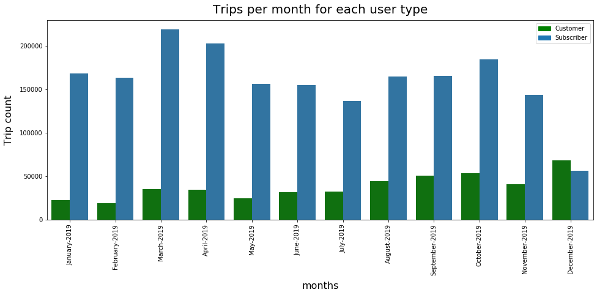

```python
# Bike rides per month for each user type
# Note that this depends on season

rcParams['figure.figsize'] = 16,6
sns.countplot(data=df_, x=df_['start_month'], hue='user_is_subscriber', palette=['g', default_color])
plt.title('Trips per month for each user type', fontsize=20, y=1.015)
plt.xlabel('months', labelpad=10, fontsize=16)
plt.ylabel('Trip count', labelpad=10, fontsize=16)
#rotating month name 90 degrees
plt.xticks(rotation=90)
# Creating artists specifically for adding to the legend (Proxy artists)
customer_legend = mpatches.Patch(color='g', label='Customer')
subscriber_legend = mpatches.Patch(color=default_color, label='Subscriber')
plt.legend(handles=[customer_legend, subscriber_legend])
plt.show();
```

looks like subscribers demand for bikes really peaked in the month on march and april but drastically drops in the month of december even below that of customer, but supprisingly that same month of december is the month where customer demand for bike peaked the most with the months of january and febuary as the months with the most drop in demand. these observations is very inconsistent and shocking to make any assumption for the reason in drops or peaks without more information

### Talk about some of the relationships you observed in this part of the investigation. How did the feature(s) of interest vary with other features in the dataset?

> peak days for both customers and subscribers differ during the month, and customers' demand tend to be more volatile

> while during the day both demands have the same peak and trough hours, but subscribers' demand is more volatile

> also, customers' demand seems to be smoother across the week, while subscribers' demand drops notably on the weekends.

### Did you observe any interesting relationships between the other features (not the main feature(s) of interest)?

> in the month of december, the demand for bike by sibscribers dropped very dramatically, i'm not sure why that is

## Multivariate Exploration

> i'll start by using a split violin plot to explore the effect of weekday on duration for each user type

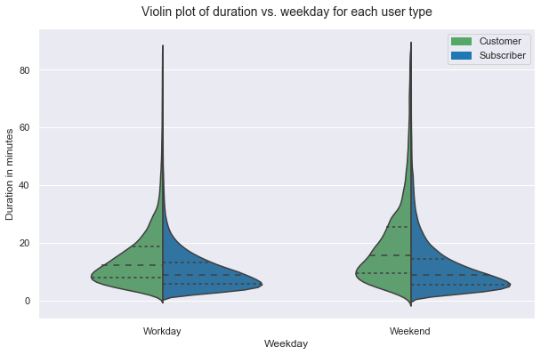

```python
# Violin plot of `is_weekend` vs `duration` for each user type
rcParams['figure.figsize'] = 10,6
sns.violinplot(data=df_, x='is_weekend', y='duration', hue='user_is_subscriber', inner='quartile', palette=['g', default_color], split=True)
ticks = [0, 1]
labels = ['Workday', 'Weekend']
plt.xticks(ticks, labels)
plt.title('Violin plot of duration vs. weekday for each user type', fontsize=14, y=1.025)
plt.xlabel('Weekday')
plt.ylabel('Duration in minutes')
# Creating artists specifically for adding to the legend (Proxy artists)
customer_legend = mpatches.Patch(color='g', label='Customer')
subscriber_legend = mpatches.Patch(color=default_color, label='Subscriber')
plt.legend(handles=[customer_legend, subscriber_legend])
plt.show();
```

duration distribution has more spread on weekends for both user types, and the meadian trip duration for customers has more spread and customers tend, on average, to take longer trips, and their trips' durations vary more compared to subscribers.

i will further explore this finding on monthly basis below in a dual axis chart.

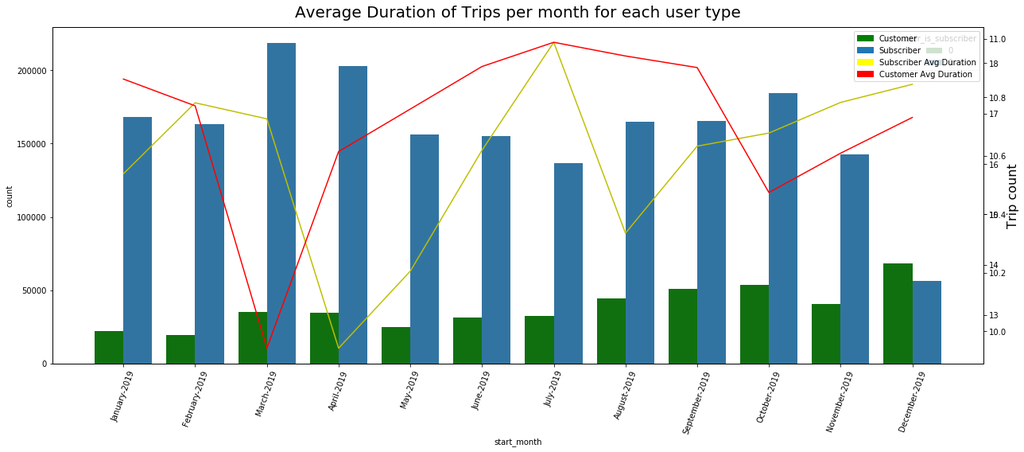

```python
#creating duration columns for each user types
df_["customer_durations"] = df_.duration[customer]
df_["subscriber_durations"] = df_.duration[subscriber]

#grouping mean duration for each user type
customer_avg_duration = df_.groupby(["start_month"]).agg(mean_duration=("customer_durations", "mean"))
subscriber_avg_duration = df_.groupby(["start_month"]).agg(mean_duration=("subscriber_durations", "mean"))

c = np.array(customer_avg_duration)
s = np.array(subscriber_avg_duration)
#ploting chart
rcParams['figure.figsize'] = 18,8
g = sns.countplot(data=df_, x=df_['start_month'], hue='user_is_subscriber', palette=['g', default_color])
plt.title('Average Duration of Trips per month for each user type', fontsize=20, y=1.015)
#rotating month name 90 degrees
plt.xticks(rotation=70)

#creating secondary y axis
ax = g.twinx()
ax.plot(s, color='y')

ax2 = g.twinx()
ax2.plot(c, color='r')

plt.xlabel('months', labelpad=10, fontsize=16)
plt.ylabel('Trip count', labelpad=10, fontsize=16)

# Creating artists specifically for adding to the legend (Proxy artists)
customer_legend = mpatches.Patch(color='g', label='Customer')
subscriber_legend = mpatches.Patch(color=default_color, label='Subscriber')
customer_trips_duration_legend = mpatches.Patch(color='r', label='Customer Avg Duration')
subscriber_trips_duration = mpatches.Patch(color='yellow', label='Subscriber Avg Duration')


plt.tight_layout()
plt.legend(handles=[customer_legend, subscriber_legend, subscriber_trips_duration, customer_trips_duration_legend])

plt.show();
```

```python
cus_avg_duration = df_.groupby(["user_is_subscriber"]).agg(mean_duration=("customer_durations", "mean"))
sub_avg_duration = df_.groupby(["user_is_subscriber"]).agg(mean_duration=("subscriber_durations", "mean"))
print(cus_avg_duration)
print(sub_avg_duration)
```

```
                    mean_duration
user_is_subscriber
0                        16.40446
1                             NaN
                    mean_duration
user_is_subscriber
0                             NaN
1                       10.571688
```

just as expected from the above multivariate exploration, the mean trip duration for customer is higher than that of subscribers

### Talk about some of the relationships you observed in this part of the investigation. Were there features that strengthened each other in terms of looking at your feature(s) of interest?

> For my multivariate exploration, i focused on the effect of user type in terms of weekdays and months just like i did in my bivariate exploration and i found that the median trip duration for customers is higher on all weekdays, and that customers' distribution have higher spread on all weekdays; customers tend, on average, to take longer trips, and their trips' durations vary more compared to subscribers.and also, the monthly average trip duration of customers is higher than that of subscribers

### Were there any interesting or surprising interactions between features?

> the findings i made in my multivariate exploration is in line with my findings in my bivariate explorations

## Conclusions

> when are most trips taken in terms of time of day or month of the year?

for this question, i made a barchart and a piechart which showed in percentage when most trips are taken in terms of time of day and most trips(37.3%) are taken late hours(from 5pm-3am) this was arrived at by splitting the start_time to represent early(from 3am-11am), mid-day(from 11am-5pm) and late(from 5pm-3am)

for weekday, i made a label column for days of the week and represented the day name of the start_time column with this label, then plotted a chart to show it, it appears that thursdays and tuesdays are busiest days.

and as for month, apparently the month of march is the busiest, i just plotted the column i extracted from start_time column which represented the month of each trip

> How long does the average trip take? and does this depend on if the user is a subscriber or a customer?

As shown above, the average duration for customers is 16.40446mins while that of subscribers is 10.571688mins. so customers on average take longer trips than subscribers

> and appearently, most users are subscribers which is 80.7% of the total bike users